# R学习笔记

Jia

有底色的代码框表示代码，无底色的框或者一些统计图表示代码运行结果  
mtcars是一个R内置的示例文件

# 基本操作

## 安装软件包

```
install.packages('ggplot2')
```

安装软件包ggplot2

`library(ggplot2)`

载入软件包ggplot2

`update.packages()`

更新所有的包

# Dataset

## R的数据结构

### Vactor

```r
a = c(1, 2, 5, 3, 6, -2, 4)#数字
b = c("one", "two", "three")#字符
c = c(TRUE, TRUE, TRUE, FALSE, TRUE, FALSE)#逻辑
```

Vactor 一维向量。c()函数用于创建向量。 可以储存的数据类型：数字 字符 逻辑

```r
v = c(1,4,4,3,2,2,3)
```

创建一个向量v。

```r
v[c(2,3,4)]
```

```
## [1] 4 4 3
```

返回第2,3,4个元素

```r
v[2:4]
```

```
## [1] 4 4 3
```

返回第二到第四个元素

```r
v[-2]
```

```
## [1] 1 4 3 2 2 3
```

返回除了第二个以外的元素

```r
v[-2:-4]
```

```
## [1] 1 2 2 3
```

返回除了第二到第四个元素以外的元素

```r
v[v<=3]
```

```
## [1] 1 3 2 2 3
```

返回小于等于3的元素

```r
which(v==3)
```

```
## [1] 4 7
```

返回数值等于3的元素的位置

```r
which.max(v)
```

```
## [1] 2
```

```r
which.min(v)
```

```
## [1] 1
```

最大/最小值的位置

```r
v[which.max(v)]
```

```
## [1] 4
```

最大值的值

### matrix

```r
x = matrix(1:20, nrow=5, ncol=4, byrow=TRUE)
x
```

```
##      [,1] [,2] [,3] [,4]
## [1,]    1    2    3    4
## [2,]    5    6    7    8
## [3,]    9   10   11   12
## [4,]   13   14   15   16
## [5,]   17   18   19   20
```

```r
y = matrix(1:20, nrow=5, ncol=4, byrow=FALSE)
y
```

```
##      [,1] [,2] [,3] [,4]
## [1,]    1    6   11   16
## [2,]    2    7   12   17
## [3,]    3    8   13   18
## [4,]    4    9   14   19
## [5,]    5   10   15   20
```

matrix()函数创建矩阵，即二维向量。matrix(要填入的数据,nrow=行数,ncol=列数)存储两个维度的数据，必须为同种类型。 byrow=TRUE：按照行填充数据。default=FALSE。

```r
x[2,]
```

```
## [1] 5 6 7 8
```

```r
x[,2]
```

```
## [1]  2  6 10 14 18
```

```r
x[1,4]
```

```
## [1] 4
```

```r
x[2,c(2,4)]
```

```
## [1] 6 8
```

```r
x[3:5, 2]
```

```
## [1] 10 14 18
```

[row,colum] 和vector操作相似。注意冒号:和逗号,的区别。冒号生成一个范围，分隔起始和结束，逗号分隔维度。

```r
rnames=c("apple","banana","orange","melon","corn")
cnames=c("cat","dog","bird","pig")
x = matrix(1:20, nrow=5, ncol=4, byrow=TRUE)
rownames(x)=rnames
colnames(x)=cnames
x
```

```
##        cat dog bird pig
## apple    1   2    3   4
## banana   5   6    7   8
## orange   9  10   11  12
## melon   13  14   15  16
## corn    17  18   19  20
```

name row and column 先建立一个Vector，含有row和column的名称。然后使用rownames()/colnames()函数指定这个vector为row/column的名称。元素个数应相同。

### array

有点复杂，感觉用不到

```r
dim1 = c("A1", "A2")
dim2 = c("B1", "B2", "B3")
dim3 = c("C1", "C2", "C3", "C4")
dim4 = c("D1", "D2", "D3")
z = array(1:72, c(2, 3, 4, 3), dimnames=list(dim1, dim2, dim3, dim4))
z[1,2,3,]
```

```
## D1 D2 D3
## 15 39 63
```

array()创建多维矩阵array(要填入矩阵的数字,矩阵各个维度的行数,dimnames=各个维度的名字)。 存储多个维度的数据，必须为同种类型。 [dimension1,dimension2,dimension3,dimension4]

### DataFrame

感觉这个最常用

```r
patientID = c(1, 2, 3, 4)
age = c(25, 34, 28, 52)
diabetes = c("Type1", "Type2", "Type1", "Type1")
status = c("Poor", "Improved", "Excellent", "Poor")
patientdata = data.frame(patientID, age, diabetes, status)
patientdata
```

```
##   patientID age diabetes    status
## 1         1  25    Type1      Poor
## 2         2  34    Type2  Improved
## 3         3  28    Type1 Excellent
## 4         4  52    Type1      Poor
```

## 随机数

```r
set.seed(250)
```

给定seed随机种子来产生随机数，同一个seed产生的随机数相同

```r
a = runif(3, min=0, max=100)
a
```

```
## [1] 26.54018 77.90907 16.90836
```

- runif()产生平均分布uniform distribution的随机数runif(产生几个随机数,最小,最大)
- rnorm()产生正态分布的随机数rnorm(n,mean=0,sd=1)
- rexp()产生指数分布的随机数rexp(n,rate=1)

## 数值操作

```r
floor(a)
```

```
## [1] 26 77 16
```

向下取整

```r
ceiling(a)
```

```
## [1] 27 78 17
```

向上取整

```r
round(a,4)
```

```
## [1] 26.5402 77.9091 16.9084
```

保留四位小数

## 通过读取文件导入数据

读取的CSV数据相当于一个DataFrame

```
data1=read.csv(file="~/Rdata/EsH-CTF.csv")
```

读取本地csv文件，逗号分隔

```
data2=read.table(file="~/Rdata/EsH-noCTF.csv")
```

读取本地文件，table分隔

```r
data3=read.csv("http://www.macalester.edu/~kaplan/ISM/datasets/swim100m.csv")
```

读取网络上的csv文件

```r
attach(data3)
```

将读取到的data3中row和column的变量名新建成R的变量（向量）  
detach()函数逆向操作

# Graphs

## 类型

有哪些种类的图

```r
set.seed(123)
x=rnorm(1000,mean=100,sd=10)
set.seed(234)
y=rnorm(1000,mean=100,sd=10)
```

先生成一个x,y的值，用于后面演示。x，y分别是1000个按正态分布的随机数

### histograms

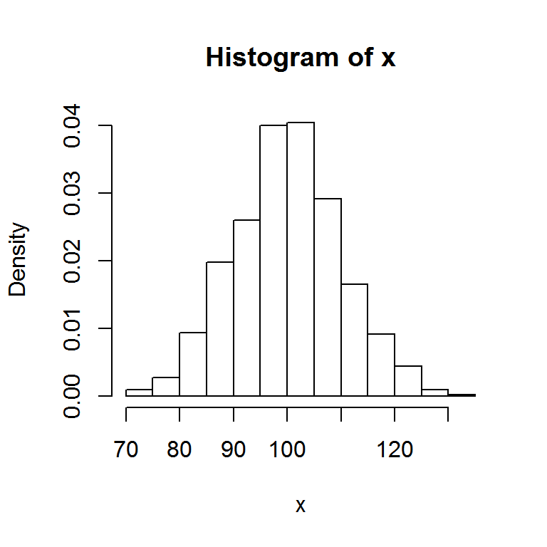

```r
hist(x,breaks=20,freq = FALSE)
```

绘制histograms的函数hist()

### DensityPlot

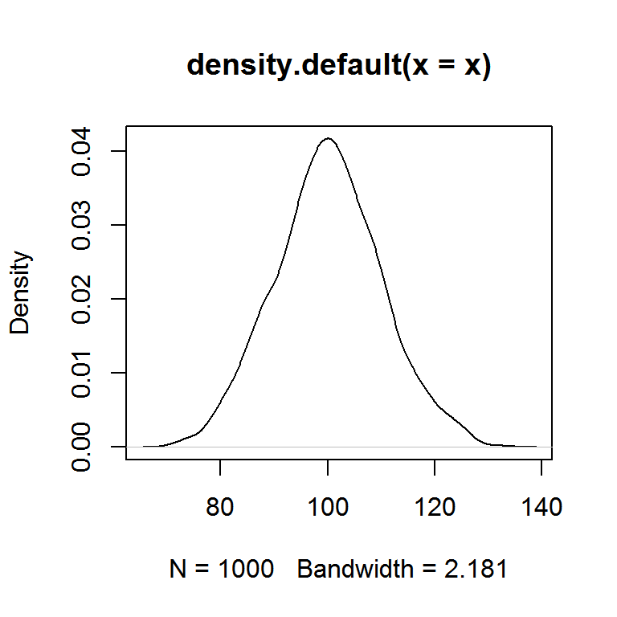

```r
plot(density(x))
```

绘制DensityPLot，先denstiy()函数再plot(denstiy())

### ScatterPlot散点图

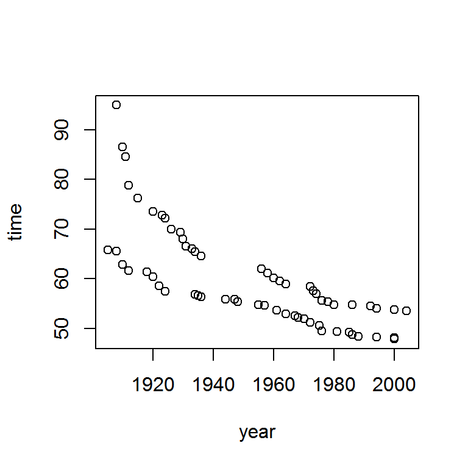

```r
plot(time~year)
```

散点图ScatterPlot使用plot()函数。这里time在y，year在x。

### BoxPlot箱线图

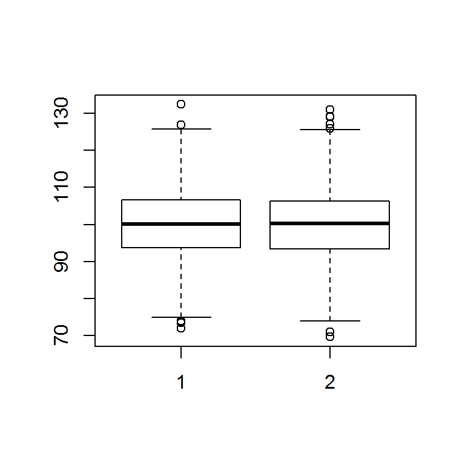

```r
boxplot(x,y)
```

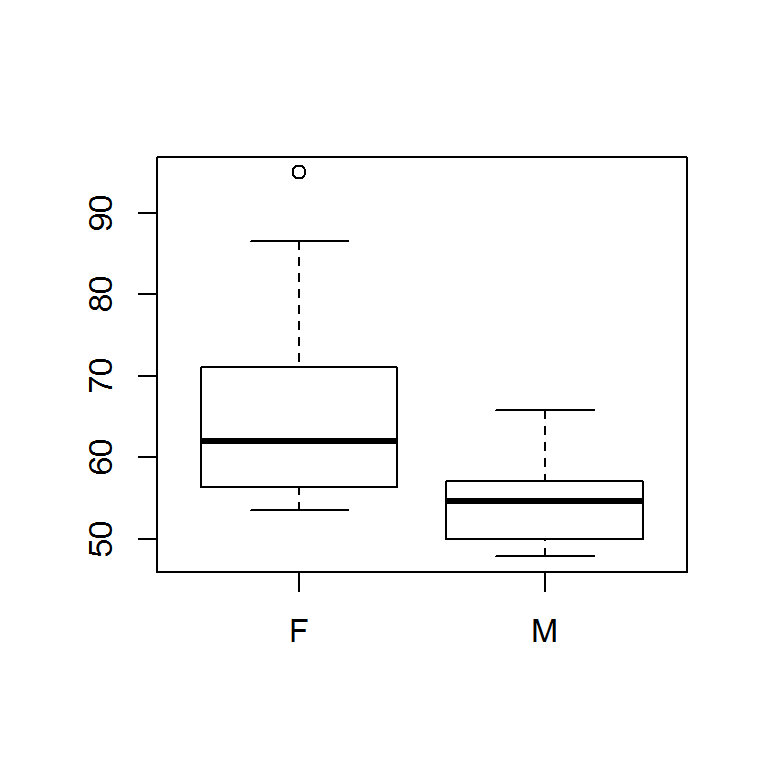

```r
boxplot(time~sex)
```

BoxPlot箱线图，boxplot()

### Q-Q Plot

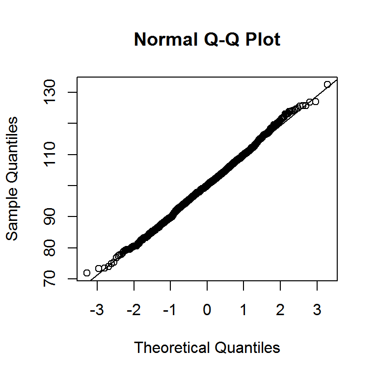

```r
qqnorm(x)
qqline(x)
```

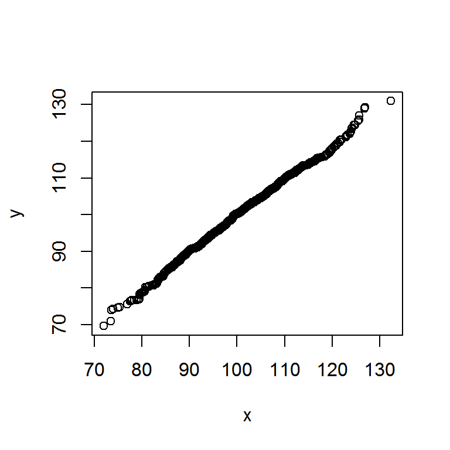

```r
qqplot(x,y)
```

Q-QPlot: qqnorm(),qqline()，qqplot() 用于检查一个数据是不是正态分布

## 图像参数设置

对于一个图像，可以分为几个部分来看。这个部分在R中由不同的函数掌握 - 图像本身 par() - 标题，坐标轴标题，坐标轴，图例 title() axis() legends() - 如果画多个图，图的位置 layout()

### Graphical Parameter

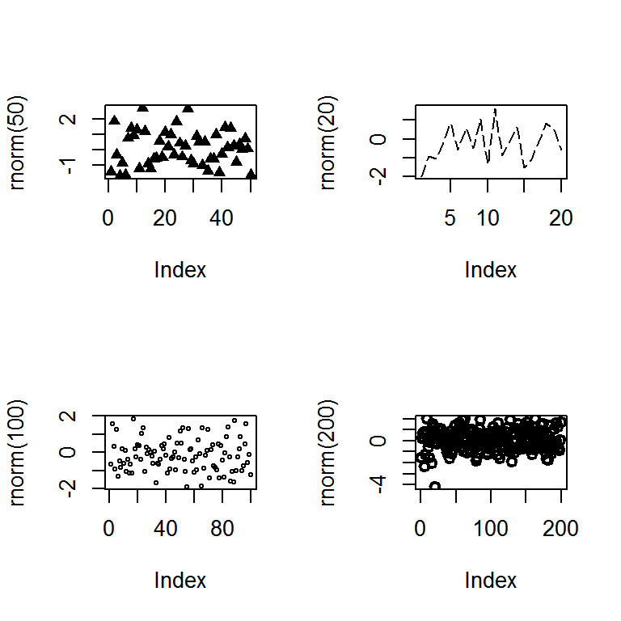

```r
par(mfrow=c(2,2))
plot(rnorm(50),pch=17)
plot(rnorm(20),type="l",lty=5)#type=line linetype=5
plot(rnorm(100),cex=0.5)#symbol size
plot(rnorm(200),lwd=2)#line Width
```

par()设置和图像本身相关的参数。mfrow=c(2,2)表示图像按照一个2*2的方式排列 type，图像的类型，**p**oint(default),**l**ine,**b**oth pch，点的形状  
lty,lineType  
cex,图标的大小倍数  
lwd，line width

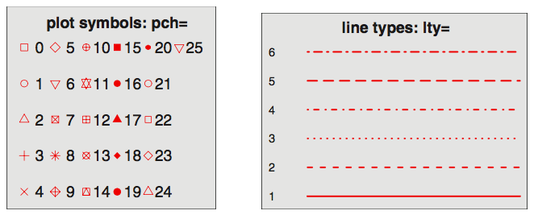